# Discovering associations between products

Alex Crespo & Oriol Ordi

12/10/2019

# Introduction

Blackwell Electronics’ board of directors is considering acquiring Electronidex, a start-up electronics online retailer. The company’s transactions of last thrity days are studied to figure out whether the adquisition would be positive or not for Blackwell Electronics.

The aim of the present report is to provide information to Blackwell’s board about Electronidex business. For this reason, Electronidex transactions are studied in order to find assosiations with the sold items to:

- Identify purchasing patterns.
- Understand the clientele of Electronidex.
- Find out if Blackweel would benefit from selling any of Electronidex’s items.

# Data exploration

The data provided and used for the further analsisys in the present task consists of one data set with all the transactions of Electronidex for the last 30 days and a list of all the products sold, classified per category. The data set contains 9836 transactions, each of them specifying only the name of the products bought. In the last 30 days, Electronidex sold a total of 125 diferent products, clasified in 16 categories. However, the categories have been renamed adjusting to Blackwell’s categories for a better and easier comparision.

# Blackwell’s business

To assess whether the acquisition of Electronidex would be beneficial to Blackwell, first, an analysis on Blackwell’s market share is needed.  
To do so, the product types sold by Blackwell are analyzed in terms of volume of sales, and in terms of profit.

The graphs (figure 1 and 2) show some interesting insight on the performance of Blackwell Electronics. The top cateogries, by far, in terms of volume of sales are **Accessories** and **Game Console**. However, the **Accessories** represent a low percentage of the profit. Instead, the **Display** and the **Game Console** are the categories that bring the most benefit to Blackwell according to the profit

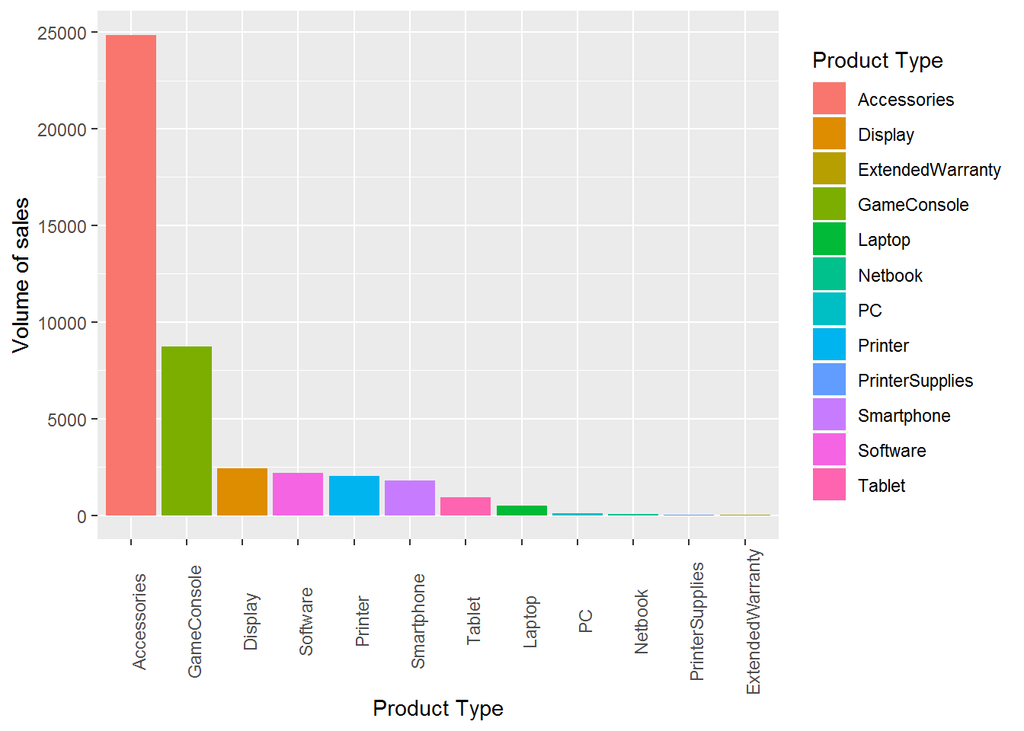

Figure 1. Plot of the volume of sales by product type of Blackwell Electronics.

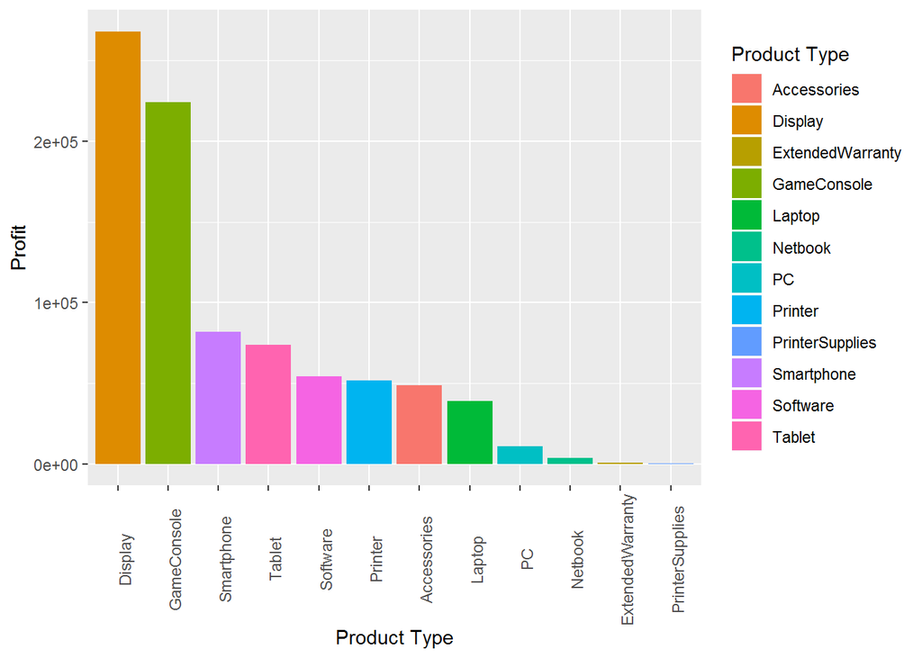

Figure 2. Plot of the profit of sales by product type of Blackwell Electronics.

# Electronidex analysis

The next step in assessing whether the acquisition of Electronidex would be beneficial to Blackwell, an analysis on Electronidex’s sales is needed.  
It must be mentioned again that the data on Electronidex’s transactions accounts for only 1 month of the company’s activities. Therefore, it has to be taken into account that the results and the conclusions drawn in this report will be limited by that fact.

### Basic analysis and analysis by categories

As a first step in the analysis of Electronidex’s transactions, the frequency in which items are bought is analyzed, to know what are the top products that the company is selling.

As the figure 3 shows, when considering all of Electronidex’s transactions, the products that are sold the most are the following:

1. iMac
2. HP Laptop
3. CYBERPOWER Gamer Desktop
4. Apple Earpods

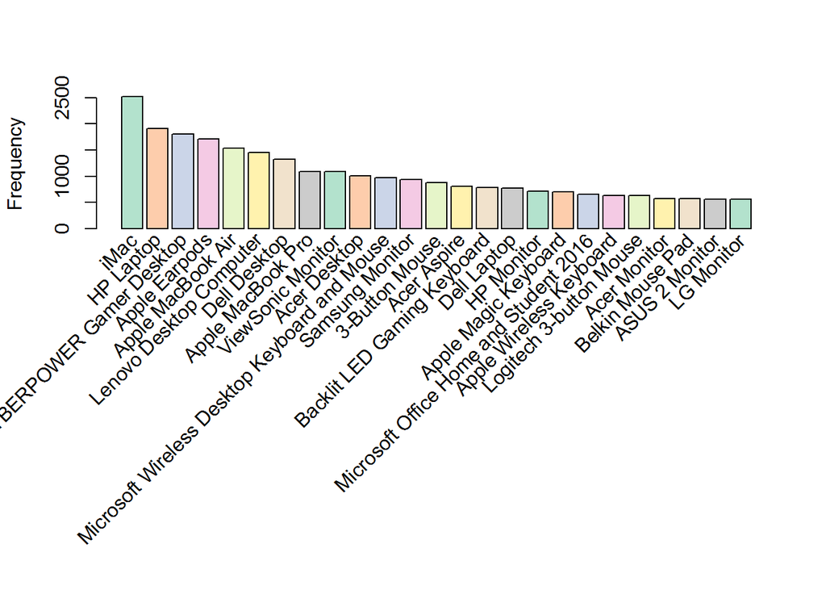

Figure 3. Item frequency plot for Electronidex 30 days transactions.

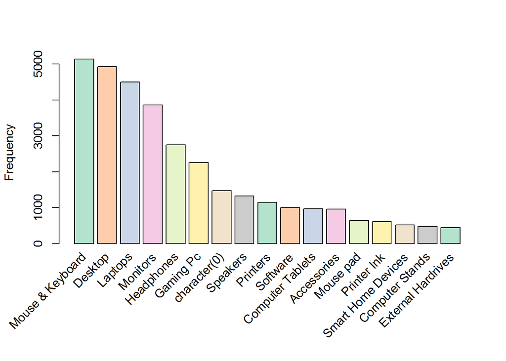

Figure 4. Product type frequency plot for Electronidex 30 days transactions.

### Initial asociacions rules

Taking the totality of the transactions, the *apriori* algorithm is used to find association rules that can help understand what products the customers of Electronidex are buying together, to see if they fit with the products that Blackwell is selling.

A very interesting fact can be seen when trying to find association rules in the Electonidex transactions. Very often, **desktops** and **laptops** are associated with other desktops and laptops, meaning that there are customers buying multiple desktop computers or laptops.

From this fact it can be concluded that some of the customers of Electronidex are not final customers, but businesses instead.

Thus, the two populations must be separated in order to truly analyze the patterns of each population and understand the customers of Electronidex.

### Understanding the clientele of Electronidex

The associations found previously show that the clienteles of electronidex business consists of final consumers and also retailers.

| Types | Restriction |
| --- | --- |
| External Hardrives | 2 |
| Mouse & Keyboard | 3 |
| Laptops | 2 |
| Desktop | 2 |
| Monitors | 2 |
| Headphones | 3 |
| Gaming Pc | 2 |
| character(0) | 2 |
| Smart Home Devices | 2 |
| Accessories | 2 |
| Mouse pad | 2 |
| Speakers | 2 |
| Printers | 2 |
| Printer Ink | 2 |
| Software | 2 |
| Computer Tablets | 2 |
| Computer Stands | 2 |

#### Consumers - retailers distribution

The transactions data sets are, thus, divided into to two: customers and retailers. The results of the division is shown in the graph of the figure 5. After the populations are separated, it can be seen that around 50% of the transactions of Electronidex are from retailers.

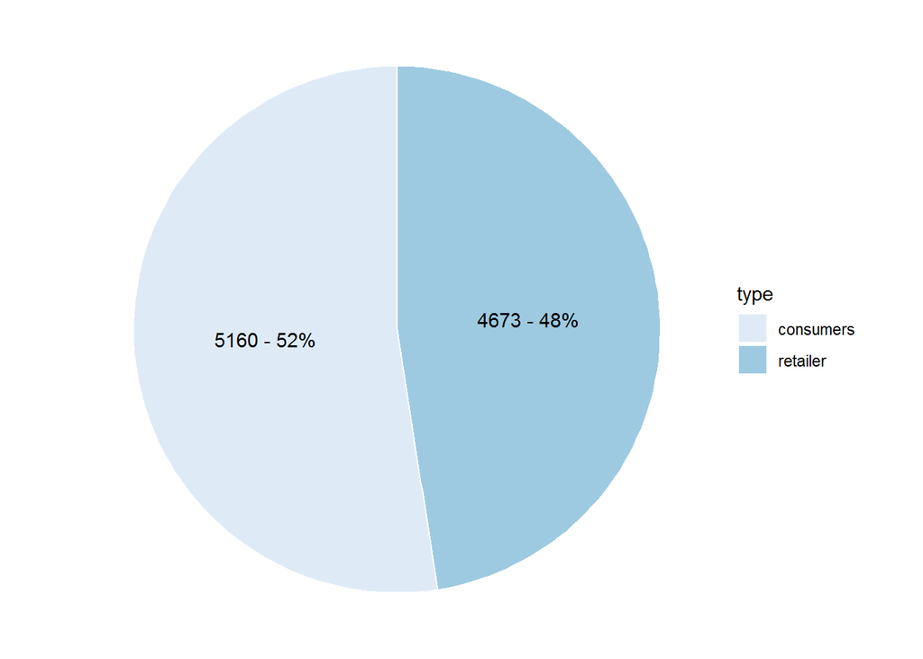

Figure 5. Pie chart for Electronidex transactions clientele.

#### Populations distribution of subsets

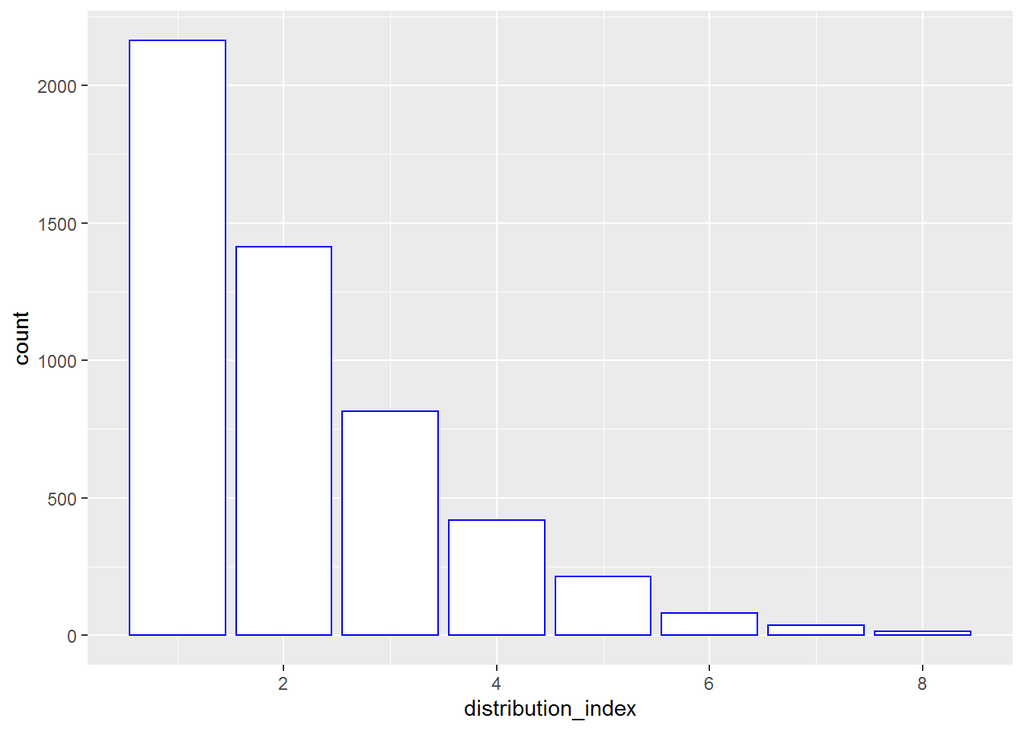

Figure 6. Distribution of the population of Electronidex customers transactions.

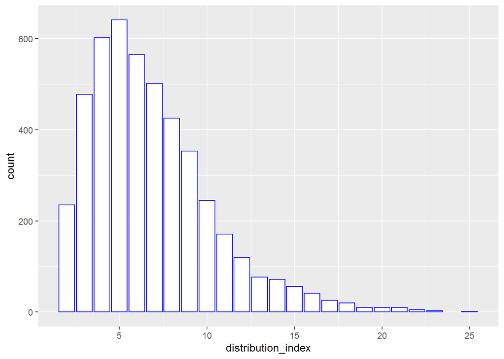

# Populations analysis and rules assosiations

Once both populations have been defined, the next step is to analyze them. To do so, the buying patterns are studied through frequency charts and associations rules for products transactions and product types transactions.

### Consumers

The figure 8 shows the frequency a product type is bought for the transactions of final customers. It can be seen that the product types which are adquired the most for consumers are **Mouse and Keyboards** and **Laptops**, in more than 30% of the transactions. Moreover, **Desktops** and **Headphones** are also aquired frequently, with a frequency higher than 20%. The case of **Gaming PCs** is a stand out. Considering that it is a category of only 3 products out of the 125 total products, the frequency of the category is higher than 10%, which means that 10% of the transactions of final consumers are gaming.

In the figure 9 the 10 most frequently bought items are shown. It stands out that the top three products are from Apple. It can be seen that Apple Earpods is a relevant product for final consumers, appearing in the 15% of their transactions and lifting the category of headphones to the top 4 in frequency. A simalr case is the CYBERPOWER Gamer Desktop, very succesfull product for Electronidex, which explains the importance of the Gaming category in the company.

Association rules are studied for the transaction of final consumers population. It is found that Apple earpods are not only a succesfull product but also that they are boosting the sales of other products, like the 3-Button Mouse and the Microsoft Wireless Desktop Keyboard and Mouse (around 20% of the times one of those items is bought, its together with Apple Earpods).  
It is also found that consumers purchasing Apple MacBook Air are unlikely to purchase Apple Earpods, however with Apple MacBook Pro it’s the other way araound. If the company is adquired, some actions should be taken to push the purchase of Earpods when buying Apple MacBook Air, as this laptop is the most frequently bought for final consumers.

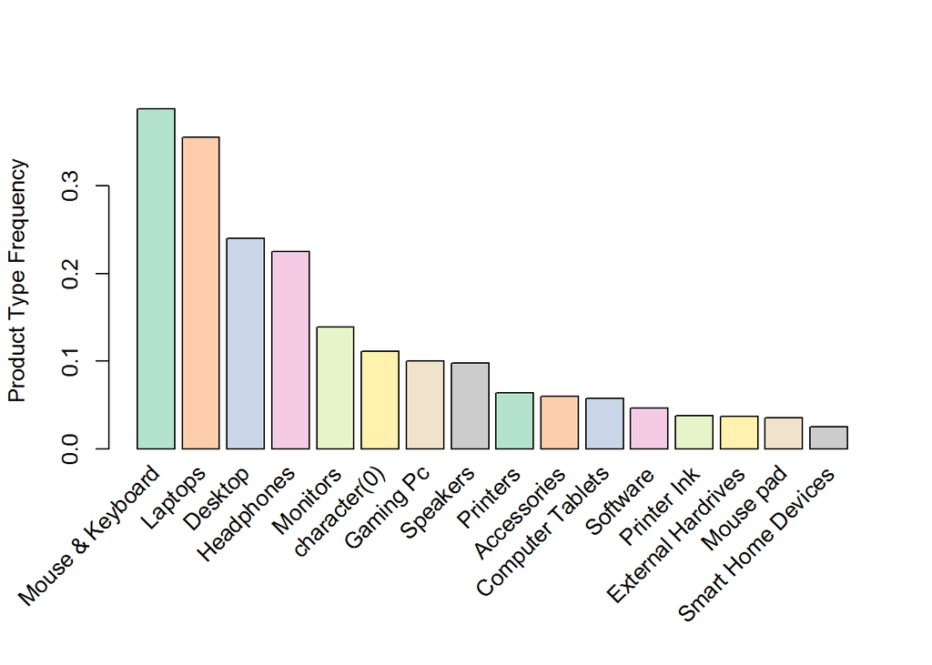

Figure 8. Product type frequency plot for Electronidex 30 days transactions for final customers

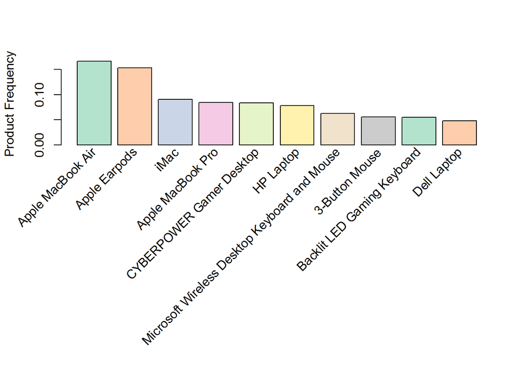

Figure 9. Item frequency plot for Electronidex 30 days transactions for final customers

### Retailers

- Non Gaming Pc’s retailers: Retailers which mainly buys non gaming pc’s.
- Gaming Pc’s retailers: Retailers which mainly buys gaming pc’s and also the most sold Pc’s iMac and HP Laptop. Monitors Samsung and Acer are mainly bought by Gaming PC’s retailers.

Monitors Samsung and Acer, and Backlit LED Gaming Keyboard are frequently bought by Gaming Pc’s retailers, and the monitors are less likely to be bought by Non Gaming Pc’s retailers. However the preference for pc types of retailers doesn’t affect the sales of the rest of products, which are sold indistinctively in any of those groups, except the ones specified previously.

.

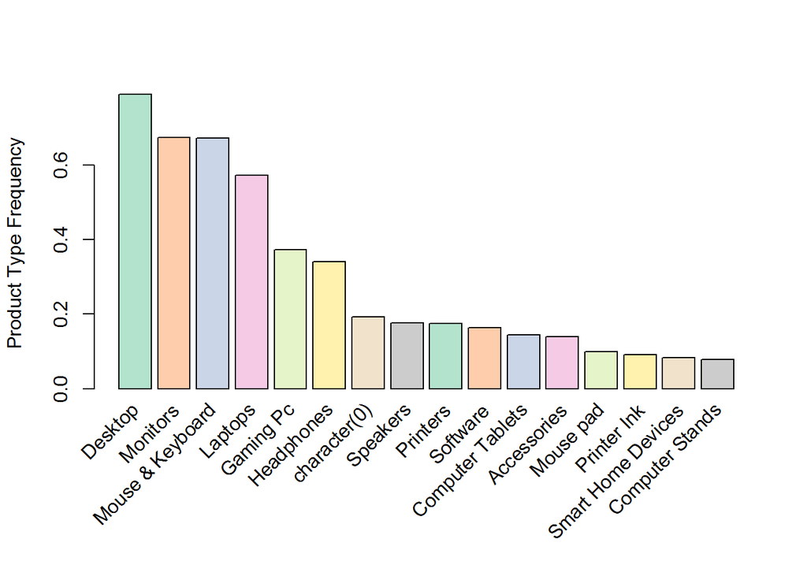

Figure 10. Product type frequency plot for Electronidex 30 days transactions for retailers

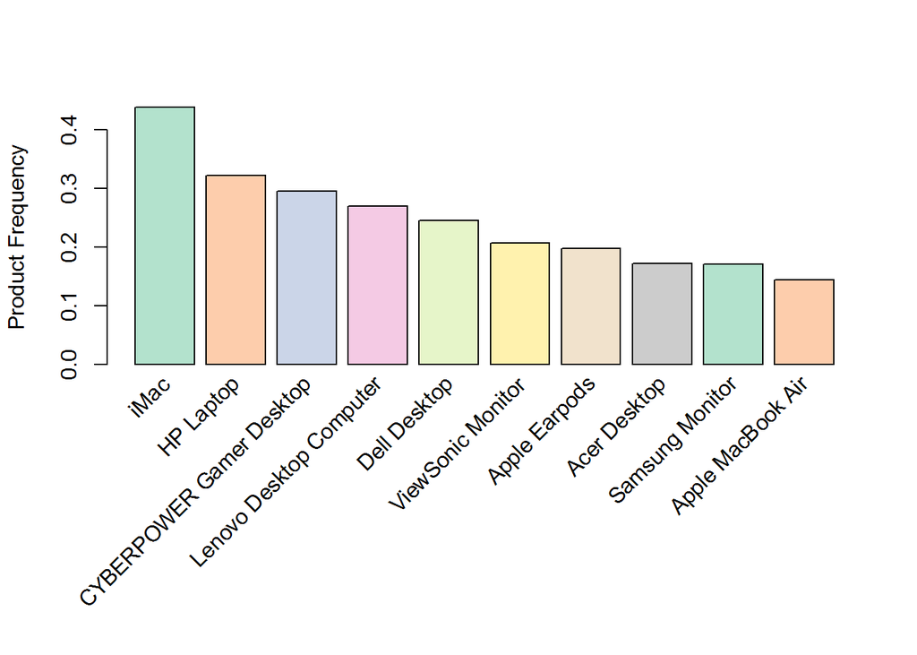

Figure 11. Items frequency plot for Electronidex 30 days transactions for retailers

# Valorations of business incorporation